# Binomial

Shih-Ni Prim

2026-09-01

# IM construction

This page shows a toy example of how to construct a possibilistic inferential model (IM) when the data is assumed to come from a Binomial distribution with $n$ trials and probability of success $\theta$.

## Relative likelihood

To construct an inferential model, we first construct the relative likelihood:
$$R(x, \theta) =
\frac{p_{\theta}(x)}{\sup_{\vartheta} p_\vartheta(x)},$$
where $p_{\theta}(x)$ is the likelihood function of Bin($n, \theta$):

$$p_\theta(x) = \begin{pmatrix} n \\ x \end{pmatrix} \theta^x
(1-\theta)^{n-x}, \quad x = 0, 1, \cdots, n, \quad \theta \in [0, 1].$$
The maximum likelihood estimator of a Binomial distribution is $\frac{x}{n}$. Thus the relative likelihood is:

$$R(x, \theta) =
\frac{p_\theta(x)}{p_{\widehat{\theta}}(x)} = \left(
\frac{n\theta}{x}\right)^x \left( \frac{n - n\theta}{n-x}\right)^{n-x}$$

## Contour function

The next step is a validation step:

$$\pi_x(\theta) = P_\theta(R(X, \theta)
\le R(x, \theta)).$$

For the Binomial distribution, there is a closed form for the contour.

$$\pi_x(\theta) = \sum_{y=0}^n 1 \{ R(y, \theta) \le R(x, \theta) \}
p_\theta(y).$$

The code below finds the contour function $\pi_x(\theta)$ given observation $x$ and the parameter of interest $\theta$.

```r
R_binomial <- function(x, n, theta){

  R <- (n*theta/x)^x * (n*(1-theta)/(n-x))^(n-x)
  return(R)

}

# closed form for x=n
contour_binomial <- function(theta, n, x){

  RHS <- R_binomial(x, n, theta)
  total <- 0
  for (i in 0:n){
    total <- total + (1*(R_binomial(i, n, theta) <= RHS)) * dbinom(i, n, theta)
  }
  return(total)

}
```

## Example demonstration

Now assume we observe $6$ successes from $10$ trilas, let’s plot the contour function.

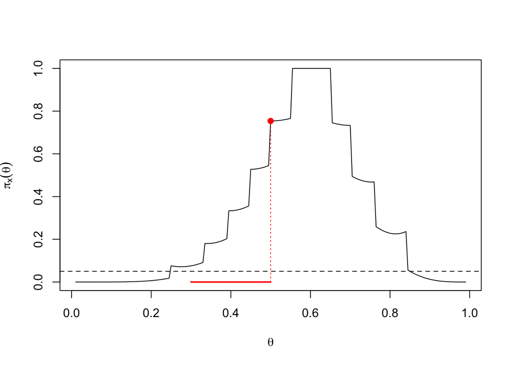

```r
n <- 10
x <- 6

theta <- seq(0.01, .99, by = .005)

pi_binomial <- contour_binomial(theta, n, x)
plot(theta, pi_binomial, type = "l", xlab = expression(theta), ylab = expression(pi[x](theta)))
abline(h=.05, lty=2)
segments(0.3, 0, 0.5, 0, col="red", lwd=2)
segments(0.5, 0, 0.5, contour_binomial(0.5, n, x), lty=3, col="red")
points(0.5, contour_binomial(0.5, n, x), col="red", pch=19)
```

As shown above, the black curve is the contour function for $x=6$. The possibility measure (or upper probability) of the hypothesis $h=[0.3,0.5]$ can be found by maximization:

$$\Pi_x(h) = \sup_{\theta \in [0.3,0.5]}
\pi_x(\theta) \approx 0.754,$$
where the red circle is.

To find a $95\%$ confidence set, the black dashed line at $0.05$ shows that the set is approximately $[0.25, 0.85]$.

# Reference

Martin, Ryan. (2026). Possibilistic inferential models: a review. *Journal of American Statistical Association,* 121 (553): 807-826. [Preprint](https://arxiv.org/abs/2507.09007).